```python
#Importing the Libraries
import matplotlib. pyplot as plt
import matplotlib
from sklearn.preprocessing import MinMaxScaler
import numpy as np
import pandas as pd
import sklearn
import sklearn.linear_model as lm
from sklearn import preprocessing
import seaborn as sns
from sklearn.model_selection import train_test_split
from sklearn import metrics
from sklearn.metrics import roc_curve,auc,recall_score,precision_score,accuracy_score,f1_score
from sklearn.metrics import confusion_matrix,average_precision_score,recall_score
import matplotlib.pyplot as plt
%matplotlib inline
from IPython.core.interactiveshell import InteractiveShell
InteractiveShell.ast_node_interactivity = "all"
```

```python
all_data = pd.read_csv("SBIBANK.csv")
#all_data=all_data.drop(['Date','Trades','Deliverable Volume','%Deliverble','Symbol','Series'],axis=1)
df=all_data.drop(['Trades','Deliverable Volume','%Deliverble','Symbol','Series'],axis=1)
df.head()
```

|  | Date | Prev Close | Open | High | Low | Last | Close | VWAP | Volume | Turnover |
| --- | --- | --- | --- | --- | --- | --- | --- | --- | --- | --- |
| 0 | 2000-01-03 | 225.60 | 236.00 | 243.65 | 234.25 | 243.65 | 243.65 | 240.83 | 2373228 | 5.715338e+13 |
| 1 | 2000-01-04 | 243.65 | 243.65 | 262.00 | 238.85 | 258.00 | 259.10 | 251.46 | 4495741 | 1.130506e+14 |
| 2 | 2000-01-05 | 259.10 | 249.00 | 264.70 | 245.00 | 249.05 | 248.45 | 252.35 | 3434058 | 8.666008e+13 |
| 3 | 2000-01-06 | 248.45 | 252.00 | 268.00 | 252.00 | 260.50 | 261.00 | 262.18 | 6658801 | 1.745817e+14 |
| 4 | 2000-01-07 | 261.00 | 261.50 | 279.90 | 255.00 | 279.00 | 273.30 | 269.02 | 7873985 | 2.118287e+14 |

# Understanding df.info()

```python
df.info()
```

```
<class 'pandas.core.frame.DataFrame'>
RangeIndex: 5577 entries, 0 to 5576
Data columns (total 10 columns):
 #   Column      Non-Null Count  Dtype
---  ------      --------------  -----
 0   Date        5577 non-null   object
 1   Prev Close  5577 non-null   float64
 2   Open        5577 non-null   float64
 3   High        5577 non-null   float64
 4   Low         5577 non-null   float64
 5   Last        5577 non-null   float64
 6   Close       5577 non-null   float64
 7   VWAP        5577 non-null   float64
 8   Volume      5577 non-null   int64
 9   Turnover    5577 non-null   float64
dtypes: float64(8), int64(1), object(1)
memory usage: 435.8+ KB
```

2.No variable column has null/missing values.

# Understanding df.describe()

```python
df.describe()
```

|  | Prev Close | Open | High | Low | Last | Close | VWAP | Volume | Turnover |
| --- | --- | --- | --- | --- | --- | --- | --- | --- | --- |
| count | 5577.000000 | 5577.000000 | 5577.000000 | 5577.000000 | 5577.000000 | 5577.000000 | 5577.000000 | 5.577000e+03 | 5.577000e+03 |
| mean | 942.427246 | 943.698072 | 958.207280 | 927.888211 | 942.314219 | 942.474260 | 943.320405 | 1.072540e+07 | 4.470337e+14 |
| std | 844.176123 | 845.288124 | 857.004322 | 832.279109 | 843.904426 | 844.154915 | 844.773419 | 1.816732e+07 | 5.020282e+14 |
| min | 141.450000 | 142.850000 | 147.950000 | 140.050000 | 140.550000 | 141.450000 | 145.900000 | 3.633000e+03 | 7.680600e+10 |
| 25% | 262.950000 | 263.700000 | 267.900000 | 259.550000 | 263.000000 | 263.000000 | 263.690000 | 1.513515e+06 | 1.531177e+14 |
| 50% | 470.400000 | 470.250000 | 479.200000 | 464.000000 | 470.850000 | 470.500000 | 471.120000 | 2.759912e+06 | 3.254686e+14 |
| 75% | 1677.800000 | 1681.000000 | 1711.000000 | 1651.000000 | 1676.350000 | 1677.800000 | 1682.090000 | 1.379997e+07 | 5.543261e+14 |
| max | 3489.950000 | 3505.000000 | 3515.000000 | 3451.350000 | 3499.000000 | 3489.950000 | 3485.250000 | 2.626771e+08 | 8.549083e+15 |

The describe() function in pandas is very handy in getting various summary statistics.This function returns the count, mean, standard deviation, minimum and maximum values and the quantiles of the data.

1.The mean value is gretaer than median value of each column which is represented by 50%(50th percentile) in index column meaning Data has positive skewed distribution.

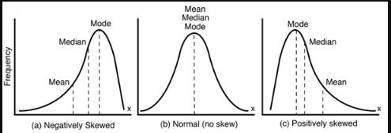

```python
df.Close.unique()
df.Close.value_counts()
```

```
array([243.65, 259.1 , 248.45, ..., 468.9 , 468.95, 474.6 ])
```

```
273.30     5
225.65     5
230.10     5
268.50     5
230.15     5
          ..
2362.35    1
2196.15    1
2137.40    1
2323.75    1
474.60     1
Name: Close, Length: 4768, dtype: int64
```

Target variable/Dependent variable is numerical in nature.

Python has a visualization library ,Seaborn which build on top of matplotlib. It provides very attractive statistical graphs in order to perform both Univariate and Multivariate analysis.

To use linear regression for modelling,its necessary to remove correlated variables to improve your model.One can find correlations using pandas “.corr()” function and can visualize the correlation matrix using a heatmap in seaborn.

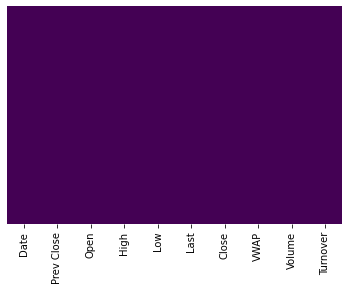

```python
sns.heatmap(df.isnull(),cbar=False,yticklabels=False,cmap = 'viridis')
```

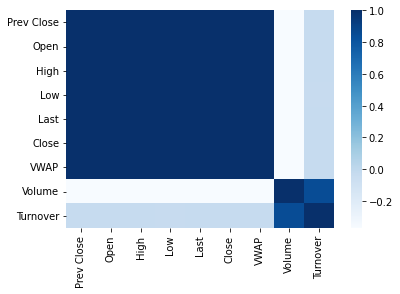

```python
plt.figure(figsize=(6,4))
sns.heatmap(df.corr(),cmap='Blues',annot=False)
```

Dark shades represents positive correlation while lighter shades represents negative correlation.If you set annot=True, you'll get values by which features are correlated to each other in grid-cells

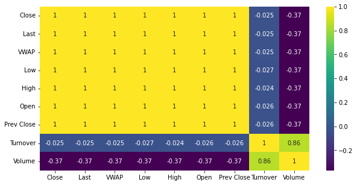

```python
#Quality correlation matrix
k = 9 #number of variables for heatmap
cols = df.corr().nlargest(k, 'Close')['Close'].index
cm = df[cols].corr()
plt.figure(figsize=(10,5))
sns.heatmap(cm, annot=True, cmap = 'viridis')
```

```python
df=df.drop(['Date'],axis=1)
df.head()
```

|  | Prev Close | Open | High | Low | Last | Close | VWAP | Volume | Turnover |
| --- | --- | --- | --- | --- | --- | --- | --- | --- | --- |
| 0 | 225.60 | 236.00 | 243.65 | 234.25 | 243.65 | 243.65 | 240.83 | 2373228 | 5.715338e+13 |
| 1 | 243.65 | 243.65 | 262.00 | 238.85 | 258.00 | 259.10 | 251.46 | 4495741 | 1.130506e+14 |
| 2 | 259.10 | 249.00 | 264.70 | 245.00 | 249.05 | 248.45 | 252.35 | 3434058 | 8.666008e+13 |
| 3 | 248.45 | 252.00 | 268.00 | 252.00 | 260.50 | 261.00 | 262.18 | 6658801 | 1.745817e+14 |
| 4 | 261.00 | 261.50 | 279.90 | 255.00 | 279.00 | 273.30 | 269.02 | 7873985 | 2.118287e+14 |

# To check Outliers

[output not shown]

[output not shown]

[figure not shown]

```python
fig, ax = plt.subplots()
columns = [df["Prev Close"],df["Open"], df["High"], df["Low"],df["Last"], df["VWAP"], df["Close"]]
ax.boxplot(columns, notch=True, patch_artist=True)
plt.xticks([1, 2,3,4,5,6,7], ['Prev Close', 'Open','High', 'Low','Last', 'VWAP','Close'])
# Adding title
plt.title("Customized box plot for HDFC DATASET")
plt.show()
```

```python
columns = [df["Prev Close"],df["Open"], df["High"], df["Low"],df["Last"], df["VWAP"], df["Close"]]
Prev_Close_list=df['Prev Close'].tolist()
Open_list=df['Open'].tolist()
High_list=df['High'].tolist()
Low_list=df['Low'].tolist()
Last_list=df['Last'].tolist()
VWAP_list=df['VWAP'].tolist()
Close_list=df['Close'].tolist()
total=len(Close_list);
TARGET0=[]
TARGET1=[]
TARGET2=[]
TARGET3=[]
TARGET4=[]
TARGET5=[]
TARGET6=[]
for j in range(0,len(columns)):
  median = np.median(columns[j])
  upper_quartile = np.percentile(columns[j], 75)
  lower_quartile = np.percentile(columns[j], 25)
  iqr = upper_quartile - lower_quartile
  upper_whisker = columns[j][columns[j]<=upper_quartile+1.5*iqr].max()
  lower_whisker = columns[j][columns[j]>=lower_quartile-1.5*iqr].min()
  for i in range(0,total):

      if(j==0):
        if(columns[j][i]>lower_quartile and columns[j][i]<upper_quartile):
          TARGET0.append('iqr')
        elif(columns[j][i]>upper_whisker):
          TARGET0.append('upper_whisker')
        elif(columns[j][i]<lower_whisker):
          TARGET0.append('lower_whisker')
        else:
          TARGET0.append('dontcare')
      elif(j==1):
        if(columns[j][i]>lower_quartile and columns[j][i]<upper_quartile):
          TARGET1.append('iqr')
        elif(columns[j][i]>upper_whisker):
          TARGET1.append('upper_whisker')
        elif(columns[j][i]<lower_whisker):
          TARGET1.append('lower_whisker')
        else:
          TARGET1.append('dontcare')
      elif(j==2):
        if(columns[j][i]>lower_quartile and columns[j][i]<upper_quartile):
          TARGET2.append('iqr')
        elif(columns[j][i]>upper_whisker):
          TARGET2.append('upper_whisker')
        elif(columns[j][i]<lower_whisker):
          TARGET2.append('lower_whisker')
        else:
          TARGET2.append('dontcare')
      elif(j==3):
        if(columns[j][i]>lower_quartile and columns[j][i]<upper_quartile):
          TARGET3.append('iqr')
        elif(columns[j][i]>upper_whisker):
          TARGET3.append('upper_whisker')
        elif(columns[j][i]<lower_whisker):
          TARGET3.append('lower_whisker')
        else:
          TARGET3.append('dontcare')
      elif(j==4):
        if(columns[j][i]>lower_quartile and columns[j][i]<upper_quartile):
          TARGET4.append('iqr')
        elif(columns[j][i]>upper_whisker):
          TARGET4.append('upper_whisker')
        elif(columns[j][i]<lower_whisker):
          TARGET4.append('lower_whisker')
        else:
          TARGET4.append('dontcare')
      elif(j==5):
        if(columns[j][i]>lower_quartile and columns[j][i]<upper_quartile):
          TARGET5.append('iqr')
        elif(columns[j][i]>upper_whisker):
          TARGET5.append('upper_whisker')
        elif(columns[j][i]<lower_whisker):
          TARGET5.append('lower_whisker')
        else:
          TARGET5.append('dontcare')
      elif(j==6):
        if(columns[j][i]>lower_quartile and columns[j][i]<upper_quartile):
          TARGET6.append('iqr')
        elif(columns[j][i]>upper_whisker):
          TARGET6.append('upper_whisker')
        elif(columns[j][i]<lower_whisker):
          TARGET6.append('lower_whisker')
        else:
          TARGET6.append('dontcare')
```

```python
df0=pd.DataFrame(TARGET0)
df1=pd.DataFrame(TARGET1)
df2=pd.DataFrame(TARGET2)
df3=pd.DataFrame(TARGET3)
df4=pd.DataFrame(TARGET4)
df5=pd.DataFrame(TARGET5)
df6=pd.DataFrame(TARGET6)
df['Prev_Close_list']=df0
df['Open_list']=df1
df['High_list']=df2
df['Low_list']=df3
df['Last_list']=df4
df['VWAP_list']=df5
df['Close_list']=df6
df.head(10)
```

|  | Prev Close | Open | High | Low | Last | Close | VWAP | Volume | Turnover | Prev_Close_list | Open_list | High_list | Low_list | Last_list | VWAP_list | Close_list |
| --- | --- | --- | --- | --- | --- | --- | --- | --- | --- | --- | --- | --- | --- | --- | --- | --- |
| 0 | 225.60 | 236.00 | 243.65 | 234.25 | 243.65 | 243.65 | 240.83 | 2373228 | 5.715338e+13 | dontcare | dontcare | dontcare | dontcare | dontcare | dontcare | dontcare |
| 1 | 243.65 | 243.65 | 262.00 | 238.85 | 258.00 | 259.10 | 251.46 | 4495741 | 1.130506e+14 | dontcare | dontcare | dontcare | dontcare | dontcare | dontcare | dontcare |
| 2 | 259.10 | 249.00 | 264.70 | 245.00 | 249.05 | 248.45 | 252.35 | 3434058 | 8.666008e+13 | dontcare | dontcare | dontcare | dontcare | dontcare | dontcare | dontcare |
| 3 | 248.45 | 252.00 | 268.00 | 252.00 | 260.50 | 261.00 | 262.18 | 6658801 | 1.745817e+14 | dontcare | dontcare | iqr | dontcare | dontcare | dontcare | dontcare |
| 4 | 261.00 | 261.50 | 279.90 | 255.00 | 279.00 | 273.30 | 269.02 | 7873985 | 2.118287e+14 | dontcare | dontcare | iqr | dontcare | iqr | iqr | iqr |
| 5 | 273.30 | 280.00 | 289.85 | 265.20 | 266.00 | 269.50 | 279.79 | 5519316 | 1.544248e+14 | iqr | iqr | iqr | iqr | iqr | iqr | iqr |
| 6 | 269.50 | 266.80 | 267.00 | 247.95 | 247.95 | 247.95 | 254.66 | 2427606 | 6.182191e+13 | iqr | iqr | dontcare | dontcare | dontcare | dontcare | dontcare |
| 7 | 247.95 | 244.00 | 251.50 | 236.60 | 244.00 | 244.75 | 243.71 | 2805072 | 6.836162e+13 | dontcare | dontcare | dontcare | dontcare | dontcare | dontcare | dontcare |
| 8 | 244.75 | 246.00 | 255.60 | 243.10 | 243.15 | 244.50 | 250.04 | 3226776 | 8.068349e+13 | dontcare | dontcare | dontcare | dontcare | dontcare | dontcare | dontcare |
| 9 | 244.50 | 245.00 | 245.00 | 238.10 | 239.05 | 239.20 | 240.55 | 1506543 | 3.624058e+13 | dontcare | dontcare | dontcare | dontcare | dontcare | dontcare | dontcare |

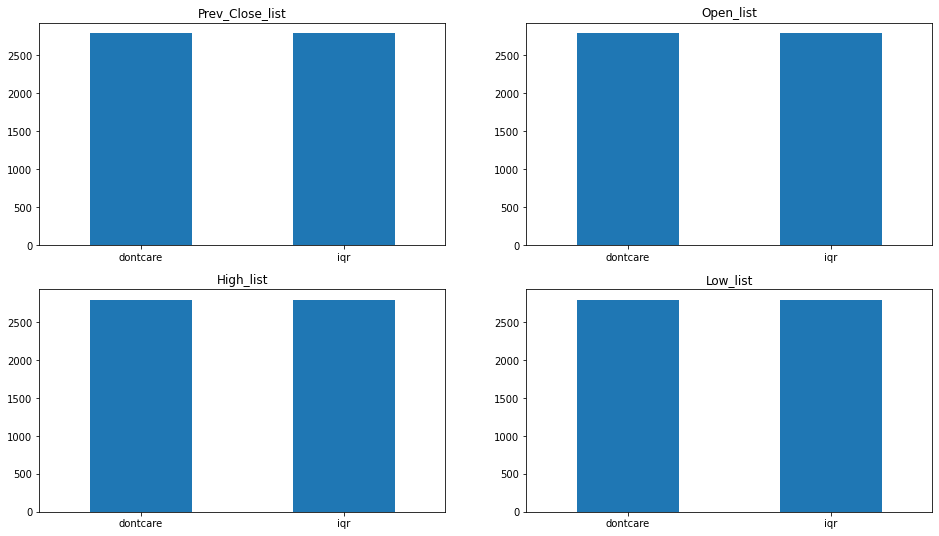

```python
plt.subplot(221)
df['Prev_Close_list'].value_counts().plot(kind='bar', title='Prev_Close_list', figsize=(16,9))
plt.xticks(rotation=0)

plt.subplot(222)
df['Open_list'].value_counts().plot(kind='bar', title='Open_list', figsize=(16,9))
plt.xticks(rotation=0)

plt.subplot(223)
df['High_list'].value_counts().plot(kind='bar', title='High_list', figsize=(16,9))
plt.xticks(rotation=0)

plt.subplot(224)
df['Low_list'].value_counts().plot(kind='bar', title='Low_list', figsize=(16,9))
plt.xticks(rotation=0)
```

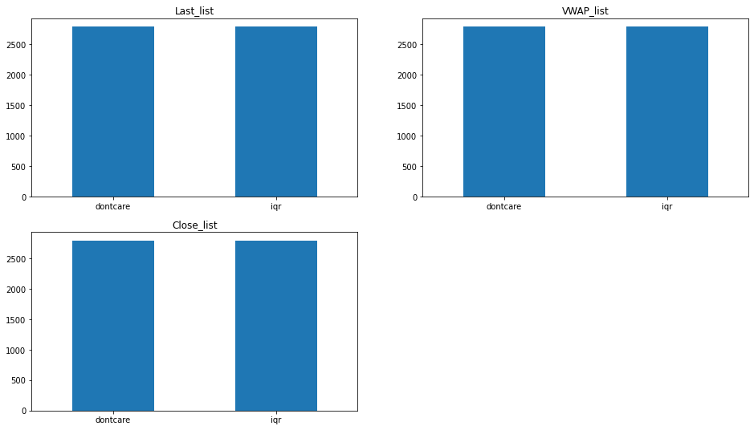

```python
plt.subplot(221)
df['Last_list'].value_counts().plot(kind='bar', title='Last_list', figsize=(16,9))
plt.xticks(rotation=0)

plt.subplot(222)
df['VWAP_list'].value_counts().plot(kind='bar', title='VWAP_list', figsize=(16,9))
plt.xticks(rotation=0)

plt.subplot(223)
df['Close_list'].value_counts().plot(kind='bar', title='Close_list', figsize=(16,9))
plt.xticks(rotation=0)
```

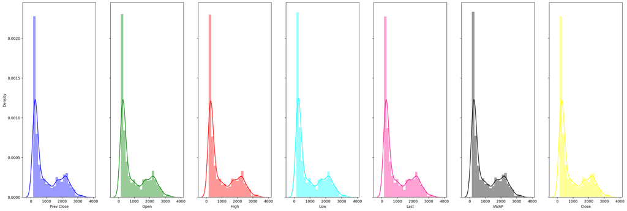

```python
import matplotlib. pyplot as plt
columns = [df["Prev Close"],df["Open"], df["High"], df["Low"],df["Last"], df["VWAP"], df["Close"]]
fig, axes = plt.subplots(1, 7, figsize=(30,10), sharey=True, dpi=200)
sns.distplot(columns[0] , color="blue", ax=axes[0], axlabel='Prev Close')
sns.distplot(columns[1] , color="green", ax=axes[1], axlabel='Open')
sns.distplot(columns[2] , color="red", ax=axes[2], axlabel='High')
sns.distplot(columns[3] , color="cyan", ax=axes[3], axlabel='Low')
sns.distplot(columns[4] , color="deeppink", ax=axes[4], axlabel='Last')
sns.distplot(columns[5] , color="black", ax=axes[5], axlabel='VWAP')
sns.distplot(columns[6] , color="yellow", ax=axes[6], axlabel='Close')
#plt.xlim(50,75);
```

```python
for k in columns:
  print(k.skew(),'\n')
```

```
0.8783936749441797

0.878952270106649

0.8712277243366914

0.8860778229017688

0.8784032019669104

0.878206300233108

0.878465765072603
```

```python
for k in columns:
   print(k.kurt(),'\n')
```

```
-0.6555201468490366

-0.6546885886098961

-0.674431901998902

-0.6363976543687033

-0.655629407254462

-0.6564065081058343

-0.6552742009438206
```

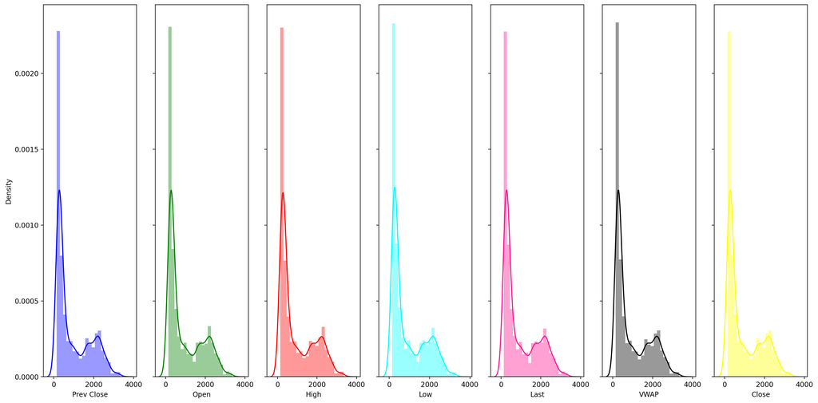

```python
import matplotlib. pyplot as plt
columns = [df["Prev Close"],df["Open"], df["High"], df["Low"],df["Last"], df["VWAP"], df["Close"]]
fig, axes = plt.subplots(1, 7, figsize=(20,10), sharey=True, dpi=200)
sns.distplot(columns[0] , color="blue", ax=axes[0], axlabel='Prev Close')
sns.distplot(columns[1] , color="green", ax=axes[1], axlabel='Open')
sns.distplot(columns[2] , color="red", ax=axes[2], axlabel='High')
sns.distplot(columns[3] , color="cyan", ax=axes[3], axlabel='Low')
sns.distplot(columns[4] , color="deeppink", ax=axes[4], axlabel='Last')
sns.distplot(columns[5] , color="black", ax=axes[5], axlabel='VWAP')
sns.distplot(columns[6] , color="yellow", ax=axes[6], axlabel='Close')
```

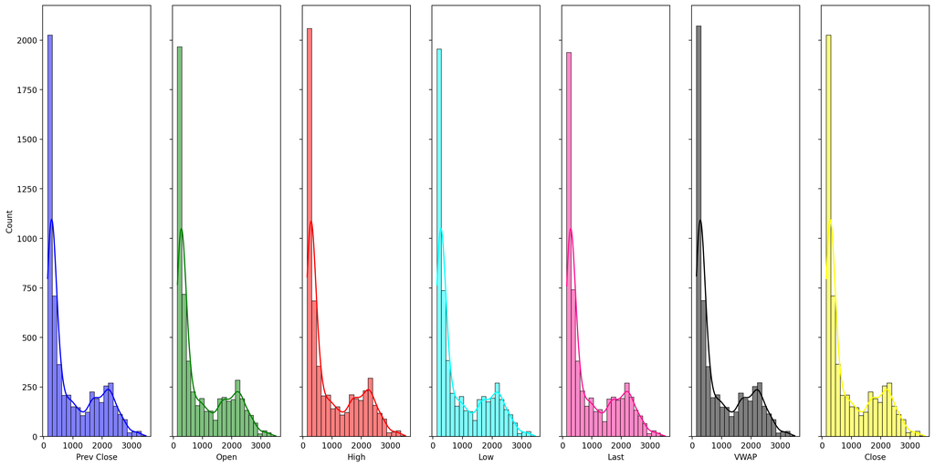

```python
import matplotlib. pyplot as plt
columns = [df["Prev Close"],df["Open"], df["High"], df["Low"],df["Last"], df["VWAP"], df["Close"]]
fig, axes = plt.subplots(1, 7, figsize=(20,10), sharey=True, dpi=200)
sns.histplot(columns[0] , color="blue", ax=axes[0], kde = True)
sns.histplot(columns[1] , color="green", ax=axes[1], kde = True)
sns.histplot(columns[2] , color="red", ax=axes[2], kde = True)
sns.histplot(columns[3] , color="cyan", ax=axes[3], kde = True)
sns.histplot(columns[4] , color="deeppink", ax=axes[4], kde = True)
sns.histplot(columns[5] , color="black", ax=axes[5], kde = True)
sns.histplot(columns[6] , color="yellow", ax=axes[6], kde = True)
```

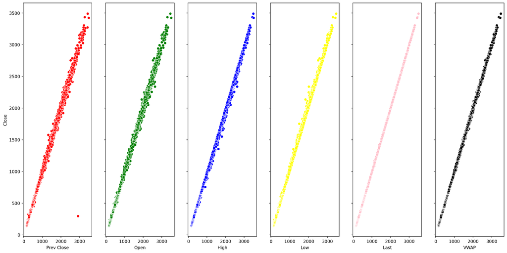

```python
import matplotlib. pyplot as plt
columns = [df["Prev Close"],df["Open"], df["High"], df["Low"],df["Last"], df["VWAP"]]
colours=["red","green","blue","yellow","pink","black"]
fig, axes = plt.subplots(1,6, figsize=(20,10), sharey=True, dpi=200)
sns.scatterplot(columns[0], df["Close"],color = colours[0],ax=axes[0])
sns.scatterplot(columns[1], df["Close"],color = colours[1],ax=axes[1])
sns.scatterplot(columns[2], df["Close"],color = colours[2],ax=axes[2])
sns.scatterplot(columns[3], df["Close"],color = colours[3],ax=axes[3])
sns.scatterplot(columns[4], df["Close"],color = colours[4],ax=axes[4])
sns.scatterplot(columns[5], df["Close"],color = colours[5],ax=axes[5])
```

```python
Close_list = df['Close'].tolist()
total=len(Close_list);
```

```python
DIFF=[]
PERCDIFF=[]
TARGET=[]
counter=0
for i in range(0,total):
  #print("i is",i)
  diff=Close_list[i]-Close_list[i-1]
  DIFF.append(diff)
  percdiff=(diff*100)/Close_list[i]
  PERCDIFF.append(percdiff)
  if(percdiff>0.5):
    TARGET.append('pos')
  else:
    TARGET.append('notpos')
```

```python
df1=pd.DataFrame(DIFF)
df2=pd.DataFrame(PERCDIFF)
df3=pd.DataFrame(TARGET)
df['DIFF']=df1
df['PERCDIFF']=df2
df['TARGET']=df3
df=df[1:]
```

```python
#DUMMY CODING USING THE LOOP STRUCTURE
for col in df.columns:
  if df[col].dtype=='object':
    df[col]=pd.Categorical(df[col]).codes
df.head(5)
```

|  | Prev Close | Open | High | Low | Last | Close | VWAP | Volume | Turnover | Prev_Close_list | Open_list | High_list | Low_list | Last_list | VWAP_list | Close_list | DIFF | PERCDIFF | TARGET |
| --- | --- | --- | --- | --- | --- | --- | --- | --- | --- | --- | --- | --- | --- | --- | --- | --- | --- | --- | --- |
| 1 | 243.65 | 243.65 | 262.00 | 238.85 | 258.00 | 259.10 | 251.46 | 4495741 | 1.130506e+14 | 0 | 0 | 0 | 0 | 0 | 0 | 0 | 15.45 | 5.962949 | 1 |
| 2 | 259.10 | 249.00 | 264.70 | 245.00 | 249.05 | 248.45 | 252.35 | 3434058 | 8.666008e+13 | 0 | 0 | 0 | 0 | 0 | 0 | 0 | -10.65 | -4.286577 | 0 |
| 3 | 248.45 | 252.00 | 268.00 | 252.00 | 260.50 | 261.00 | 262.18 | 6658801 | 1.745817e+14 | 0 | 0 | 1 | 0 | 0 | 0 | 0 | 12.55 | 4.808429 | 1 |
| 4 | 261.00 | 261.50 | 279.90 | 255.00 | 279.00 | 273.30 | 269.02 | 7873985 | 2.118287e+14 | 0 | 0 | 1 | 0 | 1 | 1 | 1 | 12.30 | 4.500549 | 1 |
| 5 | 273.30 | 280.00 | 289.85 | 265.20 | 266.00 | 269.50 | 279.79 | 5519316 | 1.544248e+14 | 1 | 1 | 1 | 1 | 1 | 1 | 1 | -3.80 | -1.410019 | 0 |

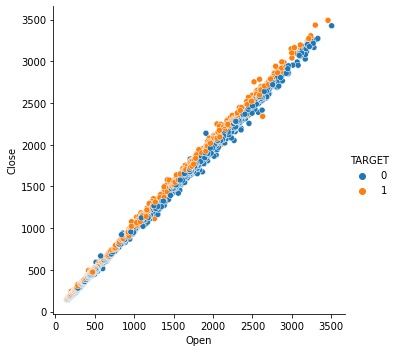

```python
sns.relplot(x='Open', y='Close', hue='TARGET', data=df)
```

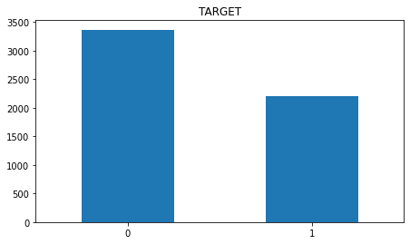

```python
plt.subplot(221)

df['TARGET'].value_counts().plot(kind='bar', title='TARGET', figsize=(16,9))

plt.xticks(rotation=0)
```

```python
!jupyter nbconvert Data_UnderstandingSBI_Dataset.ipynb
```